# Unsupervised Learning with tidylearn

```r
library(tidylearn)
library(dplyr)
library(ggplot2)

# k-means, CLARA and the gap statistic start from random draws. Seeding once
# here makes the whole page reproduce when run from the top.
set.seed(42)
```

## Two Ways In

tidylearn offers two entry points to the same algorithms, and which one you want depends on what you are doing.

`tl_model(method = "kmeans")` puts clustering behind the same signature as every supervised method, which is what you want when the clustering is a step inside a larger workflow — see `vignette("integration-workflows")`.

The `tidy_*()` family is the fuller interface, and the subject of this vignette. Each function returns a list of tibbles rather than a fitted object you have to take apart, and each has a matching `augment_*()` that glues the result back onto your data.

```r
# Same algorithm, two interfaces
model <- tl_model(iris[, 1:4], method = "kmeans", k = 3)
km <- tidy_kmeans(iris[, 1:4], k = 3)

names(km)
```

```
#> [1] "clusters" "centers"  "metrics"  "sizes"    "model"
```

Both wrap `stats::kmeans()`; the algorithms are unchanged. Reach the raw object through `model$fit$model` or `km$model` — an unsupervised `$fit` is the list of tidied components, with the wrapped object among them.

**Wrapped packages:**

- stats (`prcomp()`, `kmeans()`, `hclust()`, `cmdscale()`)
- cluster (`pam()`, `clara()`)
- dbscan for density-based clustering
- MASS (`isoMDS()`, `sammon()`)
- smacof for MDS algorithms
- arules for association rules — see `vignette("market-basket")`

## Scale First

Every distance-based method here answers a question about distance, and distance is measured in whatever units your columns happen to use. A variable measured in thousands will dominate one measured in tenths, whatever its actual relevance.

`standardize_data()` centres and scales:

```r
iris_scaled <- standardize_data(iris[, 1:4])

sapply(iris_scaled, function(x) round(c(mean = mean(x), sd = sd(x)), 3))
```

```
#>      Sepal.Length Sepal.Width Petal.Length Petal.Width
#> mean            0           0            0           0
#> sd              1           1            1           1
```

iris happens to have four variables on a similar scale, so the examples below use the raw values and stay comparable to the species labels. On real data, scale first.

## Principal Component Analysis

```r
pca <- tidy_pca(iris[, 1:4], scale = TRUE)
names(pca)
```

```
#> [1] "scores"   "loadings" "variance" "model"    "settings"
```

Accessors rather than list-digging:

```r
get_pca_variance(pca)
```

```
#> # A tibble: 4 × 5
#>   component  sdev variance prop_variance cum_variance
#>   <chr>     <dbl>    <dbl>         <dbl>        <dbl>
#> 1 PC1       1.71    2.92         0.730          0.730
#> 2 PC2       0.956   0.914        0.229          0.958
#> 3 PC3       0.383   0.147        0.0367         0.995
#> 4 PC4       0.144   0.0207       0.00518        1
```

```r
get_pca_loadings(pca, n_components = 2)
```

```
#> # A tibble: 4 × 3
#>   variable        PC1     PC2
#>   <chr>         <dbl>   <dbl>
#> 1 Sepal.Length  0.521 -0.377
#> 2 Sepal.Width  -0.269 -0.923
#> 3 Petal.Length  0.580 -0.0245
#> 4 Petal.Width   0.565 -0.0669
```

Two components carry 96% of the variance. `plot_variance_explained()` marks where a threshold is crossed:

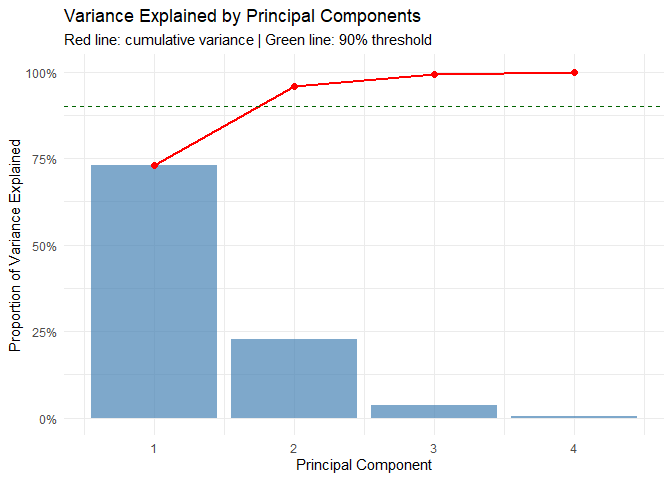

```r
plot_variance_explained(get_pca_variance(pca), threshold = 0.9)
```

`tidy_pca_screeplot()` is the conventional scree plot:

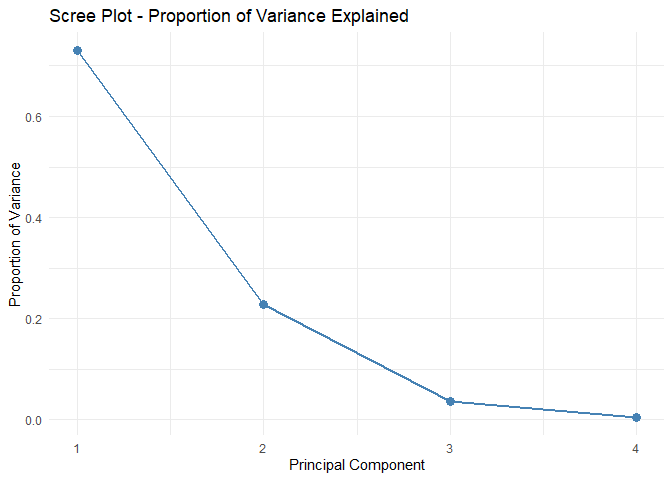

```r
tidy_pca_screeplot(pca)
```

### Scores back on the data

`augment_pca()` returns the original data with component scores appended, so the labels you already have stay attached:

```r
scored <- augment_pca(pca, iris, n_components = 2)
head(scored, 3)
```

```
#>   Sepal.Length Sepal.Width Petal.Length Petal.Width Species       PC1
#> 1          5.1         3.5          1.4         0.2  setosa -2.257141
#> 2          4.9         3.0          1.4         0.2  setosa -2.074013
#> 3          4.7         3.2          1.3         0.2  setosa -2.356335
#>          PC2
#> 1 -0.4784238
#> 2  0.6718827
#> 3  0.3407664
```

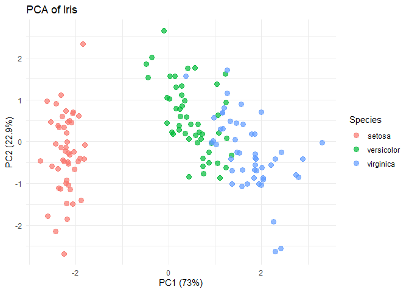

```r
ggplot(scored, aes(x = PC1, y = PC2, color = Species)) +
  geom_point(size = 3, alpha = 0.7) +
  labs(
    title = "PCA of Iris",
    x = paste0("PC1 (",
               round(get_pca_variance(pca)$prop_variance[1] * 100, 1), "%)"),
    y = paste0("PC2 (",
               round(get_pca_variance(pca)$prop_variance[2] * 100, 1), "%)")
  ) +
  theme_minimal()
```

`tidy_pca_biplot()` overlays the loadings on the same scatter, which is how you read what the components mean:

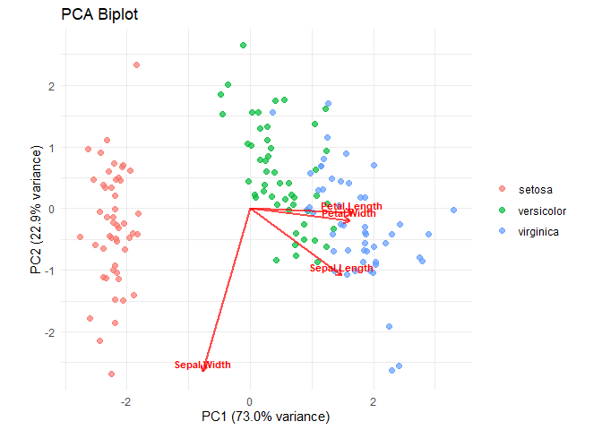

```r
tidy_pca_biplot(pca, color_by = iris$Species)
```

## How Many Clusters?

Guessing *k* and checking the answer against labels you happen to have is not a method. `optimal_clusters()` runs three criteria at once.

```r
opt <- optimal_clusters(iris[, 1:4], max_k = 8)
names(opt)
```

```
#> [1] "wss"        "silhouette" "gap"
```

```r
opt$wss
```

```
#> # A tibble: 8 × 2
#>       k tot_withinss
#>   <int>        <dbl>
#> 1     1        681.
#> 2     2        152.
#> 3     3         78.9
#> 4     4         57.2
#> 5     5         46.4
#> 6     6         39.0
#> 7     7         34.3
#> 8     8         30.0
```

```r
opt$silhouette
```

```
#> # A tibble: 7 × 2
#>       k avg_sil_width
#>   <int>         <dbl>
#> 1     2         0.681
#> 2     3         0.553
#> 3     4         0.498
#> 4     5         0.489
#> 5     6         0.365
#> 6     7         0.359
#> 7     8         0.352
```

```r
c(silhouette = attr(opt$silhouette, "optimal_k"),
  gap = opt$gap$recommended_k)
```

```
#> silhouette        gap
#>          2          6
```

The three criteria disagree, which is normal. The elbow is a judgement call, silhouette favours well-separated compact clusters, and the gap statistic compares against a null of no structure. Silhouette says 2 here because *versicolor* and *virginica* overlap; the botanical answer is 3.

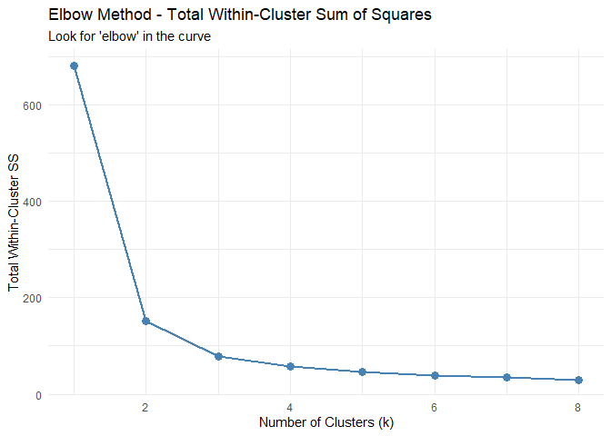

```r
plot_elbow(opt$wss, suggested_k = 3)
```

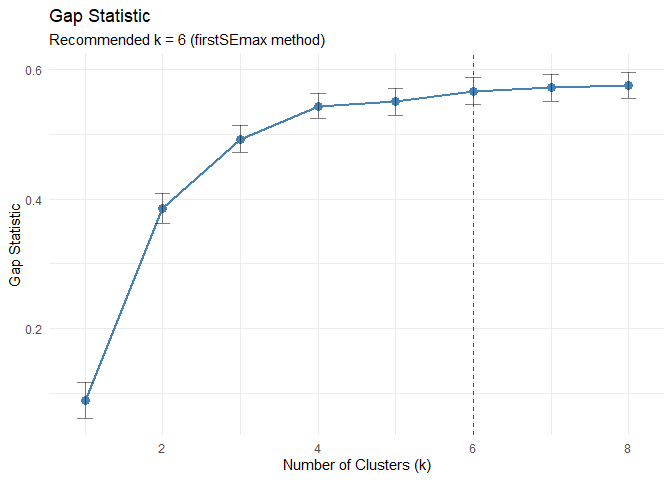

```r
plot_gap_stat(opt$gap)
```

`calc_wss()` gives the within-cluster sums of squares on their own if that is all you need:

```r
calc_wss(iris[, 1:4], max_k = 6)
```

```
#> # A tibble: 6 × 2
#>       k tot_withinss
#>   <int>        <dbl>
#> 1     1        681.
#> 2     2        152.
#> 3     3         78.9
#> 4     4         57.2
#> 5     5         46.4
#> 6     6         39.1
```

## K-means

```r
km <- tidy_kmeans(iris[, 1:4], k = 3)
km$centers
```

```
#> # A tibble: 3 × 5
#>   cluster Sepal.Length Sepal.Width Petal.Length Petal.Width
#>     <int>        <dbl>       <dbl>        <dbl>       <dbl>
#> 1       1         5.01        3.43         1.46       0.246
#> 2       2         6.85        3.07         5.74       2.07
#> 3       3         5.90        2.75         4.39       1.43
```

```r
km$clusters
```

```
#> # A tibble: 150 × 2
#>    .obs_id cluster
#>    <chr>     <int>
#>  1 1             1
#>  2 2             1
#>  3 3             1
#>  4 4             1
#>  5 5             1
#>  6 6             1
#>  7 7             1
#>  8 8             1
#>  9 9             1
#> 10 10            1
#> # ℹ 140 more rows
```

`augment_kmeans()` puts the assignment back on the data:

```r
iris_clustered <- augment_kmeans(km, iris)
table(Cluster = iris_clustered$cluster, Species = iris_clustered$Species)
```

```
#>        Species
#> Cluster setosa versicolor virginica
#>       1     50          0         0
#>       2      0          2        36
#>       3      0         48        14
```

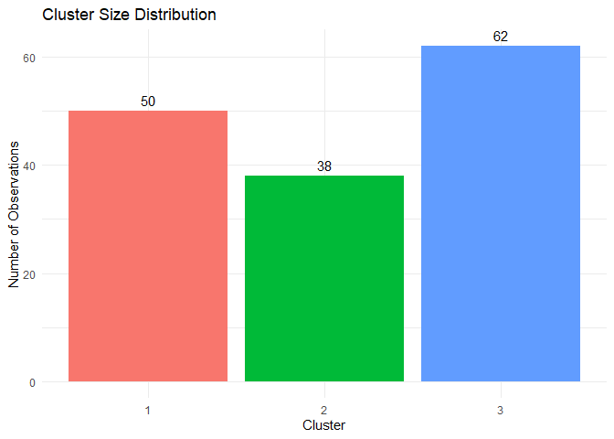

```r
plot_cluster_sizes(km$clusters$cluster)
```

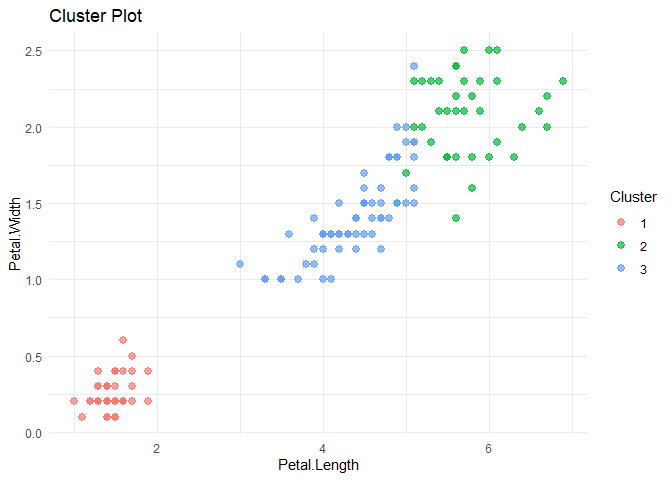

```r
plot_clusters(iris_clustered, cluster_col = "cluster",
              x_col = "Petal.Length", y_col = "Petal.Width")
```

### Was it a good clustering?

Silhouette width scores each observation on how much better it fits its own cluster than the next-nearest one. Values near 1 are comfortable, near 0 borderline, negative means the point is on the wrong side.

```r
dist_mat <- tidy_dist(iris[, 1:4])
sil <- tidy_silhouette(km$clusters$cluster, dist_mat)

sil$avg_width
```

```
#> [1] 0.552819
```

```r
sil$cluster_avg
```

```
#> # A tibble: 3 × 3
#>   cluster     n avg_sil_width
#>     <dbl> <int>         <dbl>
#> 1       1    50         0.798
#> 2       2    38         0.451
#> 3       3    62         0.417
```

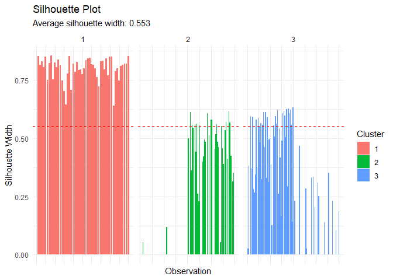

```r
plot_silhouette(sil)
```

The *setosa* cluster is clean; the other two are the *versicolor*/*virginica* boundary, and their scores say so without needing the labels. k-means numbers its clusters arbitrarily; the table above shows which number *setosa* got.

`calc_validation_metrics()` collects the summary numbers in one row:

```r
calc_validation_metrics(km$clusters$cluster, iris[, 1:4], dist_mat)
```

```
#> # A tibble: 1 × 8
#>       k min_size max_size avg_size n_noise avg_silhouette min_silhouette
#>   <int>    <int>    <int>    <dbl>   <int>          <dbl>          <dbl>
#> 1     3       38       62       50       0          0.553         0.0264
#> # ℹ 1 more variable: total_wss <dbl>
```

## PAM and CLARA

PAM picks actual observations as cluster centres, which makes it less sensitive to outliers than k-means and gives you a representative row rather than an average.

```r
pam_result <- tidy_pam(iris[, 1:4], k = 3)
pam_result$medoids
```

```
#> # A tibble: 3 × 6
#>   cluster medoid_index Sepal.Length Sepal.Width Petal.Length Petal.Width
#>     <int>        <int>        <dbl>       <dbl>        <dbl>       <dbl>
#> 1       1            8          5           3.4          1.5         0.2
#> 2       2           79          6           2.9          4.5         1.5
#> 3       3          113          6.8         3            5.5         2.1
```

```r
pam_result$silhouette_avg
```

```
#> [1] 0.552819
```

```r
table(Cluster = augment_pam(pam_result, iris)$cluster, Species = iris$Species)
```

```
#>        Species
#> Cluster setosa versicolor virginica
#>       1     50          0         0
#>       2      0         48        14
#>       3      0          2        36
```

CLARA samples rather than computing the full distance matrix, which is what makes it usable when *n* is large enough that an *n × n* matrix is not:

```r
large_data <- iris[rep(seq_len(nrow(iris)), 10), 1:4]
clara_result <- tidy_clara(large_data, k = 3, samples = 5)

table(clara_result$clusters$cluster)
```

```
#>
#>   1   2   3
#> 500 380 620
```

## Hierarchical Clustering

`tidy_hclust()` builds the tree; cutting it is a separate decision.

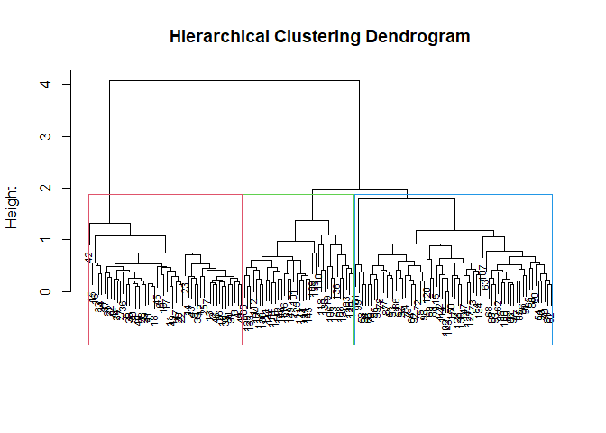

```r
hc <- tidy_hclust(iris[, 1:4], method = "average")
plot_dendrogram(hc, k = 3)
```

`optimal_hclust_k()` scores cut heights the way `optimal_clusters()` scores *k*:

```r
optimal_hclust_k(hc, method = "silhouette", max_k = 8)$optimal_k
```

```
#> [1] 2
```

```r
cuts <- tidy_cutree(hc, k = 3)
head(cuts, 3)
```

```
#> # A tibble: 3 × 2
#>   .obs_id cluster
#>   <chr>     <int>
#> 1 1             1
#> 2 2             1
#> 3 3             1
```

```r
hc_data <- augment_hclust(hc, iris, k = 3)
table(Cluster = hc_data$cluster, Species = hc_data$Species)
```

```
#>        Species
#> Cluster setosa versicolor virginica
#>       1     50          0         0
#>       2      0         50        14
#>       3      0          0        36
```

Linkage matters more than most people expect. `"average"`, `"complete"`, `"single"` and `"ward.D2"` can produce different trees from the same distances:

```r
linkages <- c("single", "average", "complete", "ward.D2")

sapply(linkages, function(m) {
  cl <- tidy_cutree(tidy_hclust(iris[, 1:4], method = m), k = 3)$cluster
  max(table(cl))
})
```

```
#>   single  average complete  ward.D2
#>       98       64       72       64
```

Single linkage chains: its largest cluster takes 98 of the 150 rows, all of *versicolor* and nearly all of *virginica*, and leaves two rows as a cluster of their own. That is a property of the linkage, not a finding about irises.

## DBSCAN

DBSCAN finds arbitrarily shaped clusters and labels sparse points as noise. It needs `eps` (the neighbourhood radius) and `minPts`. Rather than guessing, `suggest_eps()` reads it off the k-nearest-neighbour distance curve, at `k = minPts - 1` because a core point’s `minPts` includes the point itself.

```r
eps_suggestion <- suggest_eps(iris[, 1:4], minPts = 5)
eps_suggestion$eps
```

```
#> [1] 0.7179749
```

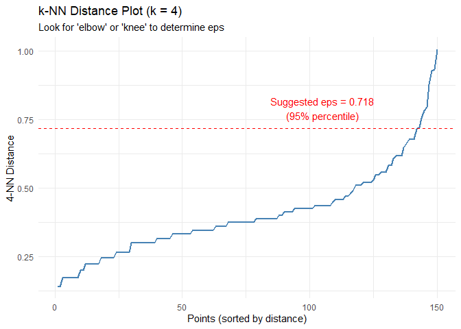

```r
plot_knn_dist(iris[, 1:4], k = 4)
```

The elbow in that curve is where points stop having close neighbours, which is the radius you want.

```r
db <- tidy_dbscan(iris[, 1:4], eps = eps_suggestion$eps, minPts = 5)

c(clusters = db$n_clusters, noise = db$n_noise)
```

```
#> clusters    noise
#>        2        3
```

```r
db_data <- augment_dbscan(db, iris)
table(Cluster = db_data$cluster, Species = db_data$Species)
```

```
#>        Species
#> Cluster setosa versicolor virginica
#>       0      0          0         3
#>       1     50          0         0
#>       2      0         50        47
```

Cluster 0 is noise, not a cluster.

`explore_dbscan_params()` sweeps the two parameters together, which is more informative than tuning either alone:

```r
explore_dbscan_params(
  iris[, 1:4],
  eps_values = c(0.4, 0.6, 0.8, 1.0),
  minPts_values = c(4, 5, 10)
)
```

```
#> # A tibble: 12 × 5
#>      eps minPts n_clusters n_noise prop_noise
#>    <dbl>  <dbl>      <int>   <int>      <dbl>
#>  1   0.4      4          4      25     0.167
#>  2   0.6      4          3       5     0.0333
#>  3   0.8      4          2       2     0.0133
#>  4   1        4          2       0     0
#>  5   0.4      5          4      32     0.213
#>  6   0.6      5          2       9     0.06
#>  7   0.8      5          2       2     0.0133
#>  8   1        5          2       0     0
#>  9   0.4     10          3      83     0.553
#> 10   0.6     10          2      13     0.0867
#> 11   0.8     10          2       5     0.0333
#> 12   1       10          2       0     0
```

Read `prop_noise` alongside `n_clusters`: a setting that finds many clusters by discarding a third of the data has not found structure.

## Multidimensional Scaling

MDS places observations so that their plotted distances reproduce their distances in the original space. Unlike PCA it can work from any distance matrix, including non-Euclidean ones.

```r
mds <- tidy_mds(iris[, 1:4], method = "classical", ndim = 2)
head(mds$config, 3)
```

```
#> # A tibble: 3 × 2
#>    Dim1   Dim2
#>   <dbl>  <dbl>
#> 1 -2.68  0.319
#> 2 -2.71 -0.177
#> 3 -2.89 -0.145
```

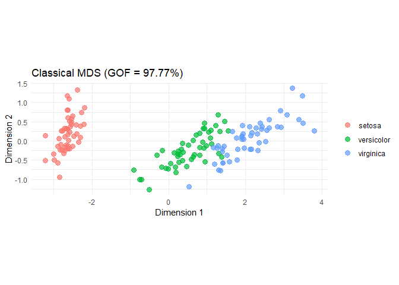

```r
plot_mds(mds, color_by = iris$Species, label_points = FALSE)
```

`method` also takes `"metric"` and `"nonmetric"` (both via smacof), `"sammon"` and `"kruskal"`. The last two minimise a stress function by dividing through the observed distances, so they need every pairwise distance to be strictly positive. iris contains one duplicated row, which is enough to stop them:

```r
tidy_mds(iris[, 1:4], method = "sammon", ndim = 2)
```

```
#> Error:
#> ! method = "sammon" needs every pairwise distance to be positive, but 1 pair(s) of observations are identical: 102 and 143. Drop the duplicates, or use method = "classical", "metric" or "nonmetric", which tolerate them.
```

Drop the duplicates and they run:

```r
distinct_iris <- iris[!duplicated(iris[, 1:4]), 1:4]
sammon <- tidy_mds(distinct_iris, method = "sammon", ndim = 2)
sammon$stress
```

```
#> [1] 0.004015053
```

Stress is the number to check before reading anything into a non-metric layout: below about 0.05 the picture is a faithful rendering of the distances, and above about 0.2 it is decoration.

## Comparing Clusterings

`compare_clusterings()` scores several partitions of the same data side by side.

```r
comparison <- compare_clusterings(
  list(
    kmeans = km$clusters$cluster,
    pam = pam_result$clusters$cluster,
    hclust = cuts$cluster,
    dbscan = db$clusters$cluster
  ),
  iris[, 1:4],
  dist_mat
)

comparison
```

```
#> # A tibble: 4 × 9
#>   method     k min_size max_size avg_size n_noise avg_silhouette min_silhouette
#>   <chr>  <int>    <int>    <int>    <dbl>   <int>          <dbl>          <dbl>
#> 1 kmeans     3       38       62     50         0          0.553         0.0264
#> 2 pam        3       38       62     50         0          0.553         0.0264
#> 3 hclust     3       36       64     50         0          0.554        -0.0901
#> 4 dbscan     2       50       97     73.5       3          0.694        -0.137
#> # ℹ 1 more variable: total_wss <dbl>
```

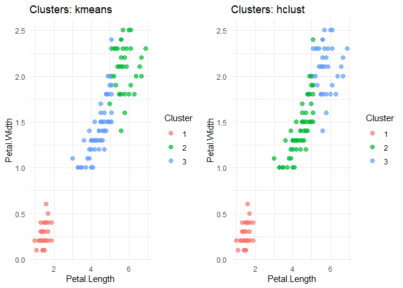

```r
plot_cluster_comparison(
  iris[, 1:4] |>
    mutate(kmeans = km$clusters$cluster, hclust = cuts$cluster),
  cluster_cols = c("kmeans", "hclust"),
  x_col = "Petal.Length",
  y_col = "Petal.Width"
)
```

The distance metric is a choice too. `compare_distances()` computes several so you can see whether your conclusion depends on it:

```r
names(compare_distances(iris[, 1:4]))
```

```
#> [1] "euclidean" "manhattan" "maximum"
```

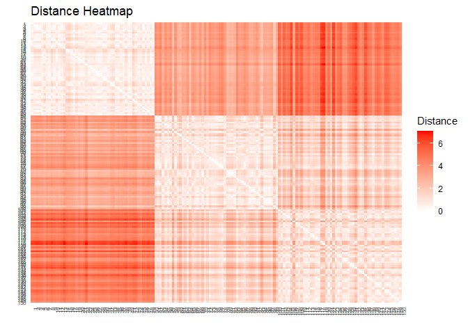

```r
plot_distance_heatmap(dist_mat)
```

Look for block structure on the diagonal — contiguous runs of small distances are what a cluster looks like here.

## A Worked Sequence

Putting the pieces in the order they belong:

```r
data_matrix <- standardize_data(iris[, 1:4])

# 1. How many clusters does the data support?
choice <- optimal_clusters(data_matrix, max_k = 8)
k <- attr(choice$silhouette, "optimal_k")
k
```

```
#> [1] 2
```

```r
# 2. Cluster at that k
final_km <- tidy_kmeans(data_matrix, k = k)

# 3. Score the result before believing it
final_sil <- tidy_silhouette(final_km$clusters$cluster, tidy_dist(data_matrix))
final_sil$avg_width
```

```
#> [1] 0.58175
```

```r
# 4. Attach the assignment and look at it
final_data <- augment_kmeans(final_km, iris)
table(Cluster = final_data$cluster, Species = final_data$Species)
```

```
#>        Species
#> Cluster setosa versicolor virginica
#>       1      0         50        50
#>       2     50          0         0
```

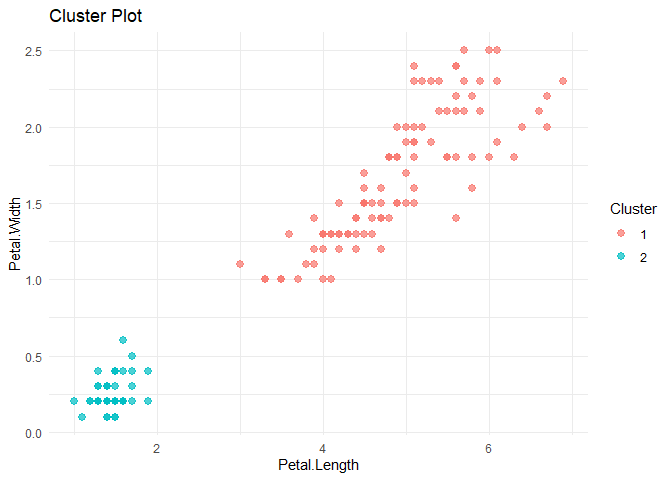

```r
plot_clusters(final_data, cluster_col = "cluster",
              x_col = "Petal.Length", y_col = "Petal.Width")
```

Silhouette chose 2, and the table shows what that means: *setosa* separated, the other two species merged. That is the honest reading of this data at this metric — the third cluster exists botanically but is not well separated in these four measurements.

## Function Reference

| Task | Function |
| --- | --- |
| Prepare | `standardize_data()`, `tidy_dist()`, `compare_distances()` |
| Choose *k* | `optimal_clusters()`, `calc_wss()`, `tidy_gap_stat()`, `optimal_hclust_k()` |
| Reduce | `tidy_pca()`, `tidy_mds()` |
| Cluster | `tidy_kmeans()`, `tidy_pam()`, `tidy_clara()`, `tidy_hclust()`, `tidy_dbscan()` |
| Attach results | `augment_pca()`, `augment_kmeans()`, `augment_pam()`, `augment_hclust()`, `augment_dbscan()` |
| Validate | `tidy_silhouette()`, `calc_validation_metrics()`, `compare_clusterings()` |
| Tune DBSCAN | `suggest_eps()`, `plot_knn_dist()`, `explore_dbscan_params()` |
| Plot | `plot_elbow()`, `plot_silhouette()`, `plot_gap_stat()`, `plot_clusters()`, `plot_cluster_sizes()`, `plot_dendrogram()`, `plot_mds()`, `plot_distance_heatmap()`, `plot_variance_explained()` |
| Accessors | `get_pca_variance()`, `get_pca_loadings()`, `tidy_cutree()` |

Association rules have their own vignette: `vignette("market-basket")`.